# Titanic_Data_Analysis

For the final project, you will conduct your own data analysis and create a file to share that documents your findings.

1. You should start by taking a look at your dataset and brainstorming **what questions you could answer using it**.
2. Then you should use **Pandas and NumPy to answer** the questions you are most interested in,
3. and **create a report** sharing the answers. You will not be required to use statistics or machine learning to complete this project, but you should make it clear in your communications that your findings are *tentative*. This project is open-ended in that we are not looking for one right answer.

Brainstorm some questions you could answer using the data set you chose, then start answering those questions. Here are some ideas to get you started:

Titanic Data

> What factors made people more likely to survive?

reference: https://www.kaggle.com/c/titanic

# Input data, get a general idea

```python
import pandas as pd
import matplotlib.pyplot as plt
import numpy as np
% matplotlib inline
titanic=pd.read_csv("titanic_data.csv")
type(titanic)
```

```
pandas.core.frame.DataFrame
```

```python
titanic.head()
```

|  | PassengerId | Survived | Pclass | Name | Sex | Age | SibSp | Parch | Ticket | Fare | Cabin | Embarked |
| --- | --- | --- | --- | --- | --- | --- | --- | --- | --- | --- | --- | --- |
| 0 | 1 | 0 | 3 | Braund, Mr. Owen Harris | male | 22.0 | 1 | 0 | A/5 21171 | 7.2500 | NaN | S |
| 1 | 2 | 1 | 1 | Cumings, Mrs. John Bradley (Florence Briggs Th... | female | 38.0 | 1 | 0 | PC 17599 | 71.2833 | C85 | C |
| 2 | 3 | 1 | 3 | Heikkinen, Miss. Laina | female | 26.0 | 0 | 0 | STON/O2. 3101282 | 7.9250 | NaN | S |
| 3 | 4 | 1 | 1 | Futrelle, Mrs. Jacques Heath (Lily May Peel) | female | 35.0 | 1 | 0 | 113803 | 53.1000 | C123 | S |
| 4 | 5 | 0 | 3 | Allen, Mr. William Henry | male | 35.0 | 0 | 0 | 373450 | 8.0500 | NaN | S |

```python
titanic.describe()
```

|  | PassengerId | Survived | Pclass | Age | SibSp | Parch | Fare |
| --- | --- | --- | --- | --- | --- | --- | --- |
| count | 891.000000 | 891.000000 | 891.000000 | 714.000000 | 891.000000 | 891.000000 | 891.000000 |
| mean | 446.000000 | 0.383838 | 2.308642 | 29.699118 | 0.523008 | 0.381594 | 32.204208 |
| std | 257.353842 | 0.486592 | 0.836071 | 14.526497 | 1.102743 | 0.806057 | 49.693429 |
| min | 1.000000 | 0.000000 | 1.000000 | 0.420000 | 0.000000 | 0.000000 | 0.000000 |
| 25% | 223.500000 | 0.000000 | 2.000000 | NaN | 0.000000 | 0.000000 | 7.910400 |
| 50% | 446.000000 | 0.000000 | 3.000000 | NaN | 0.000000 | 0.000000 | 14.454200 |
| 75% | 668.500000 | 1.000000 | 3.000000 | NaN | 1.000000 | 0.000000 | 31.000000 |
| max | 891.000000 | 1.000000 | 3.000000 | 80.000000 | 8.000000 | 6.000000 | 512.329200 |

```python
# People on board, surived number, surived rate
total= titanic["PassengerId"].size
survive= titanic["Survived"].sum()
rate=float(survive)/total
print [total, survive, rate]
```

```
[891, 342, 0.3838383838383838]
```

# Divide and conquer

From wikipedia, the real Titanic had passengers of 2224. So this example data is only **part of** the whole data, with a survival rate similar to the historical number. There are two approaches to analyze the data:

1. calculate the correlation between one factor (Pclss, Age, Sex, Fare) and survival
2. plot the distribution of survival in terms of one factor

## 0 general

Some quick ideas can be drawn from below:

1. upper class has larger survival rate
2. yonger people has slightly larger surival rate
3. more expensive fare has larger survival rate

```python
titanic.groupby('Survived').mean()
```

| Survived | PassengerId | Pclass | Age | SibSp | Parch | Fare |
| --- | --- | --- | --- | --- | --- | --- |
| 0 | 447.016393 | 2.531876 | 30.626179 | 0.553734 | 0.329690 | 22.117887 |
| 1 | 444.368421 | 1.950292 | 28.343690 | 0.473684 | 0.464912 | 48.395408 |

```python
titanic.corr()
```

|  | PassengerId | Survived | Pclass | Age | SibSp | Parch | Fare |
| --- | --- | --- | --- | --- | --- | --- | --- |
| PassengerId | 1.000000 | -0.005007 | -0.035144 | 0.036847 | -0.057527 | -0.001652 | 0.012658 |
| Survived | -0.005007 | 1.000000 | -0.338481 | -0.077221 | -0.035322 | 0.081629 | 0.257307 |
| Pclass | -0.035144 | -0.338481 | 1.000000 | -0.369226 | 0.083081 | 0.018443 | -0.549500 |
| Age | 0.036847 | -0.077221 | -0.369226 | 1.000000 | -0.308247 | -0.189119 | 0.096067 |
| SibSp | -0.057527 | -0.035322 | 0.083081 | -0.308247 | 1.000000 | 0.414838 | 0.159651 |
| Parch | -0.001652 | 0.081629 | 0.018443 | -0.189119 | 0.414838 | 1.000000 | 0.216225 |
| Fare | 0.012658 | 0.257307 | -0.549500 | 0.096067 | 0.159651 | 0.216225 | 1.000000 |

## 1 Age

Majority of passages have ages among 20~40. So it's reasonable most survived and unsurvived people are within this age groups. It's worth noting that the baby survival rate is pretty high. This is because of the "women and children first" protocol, which is a glory of humanity.

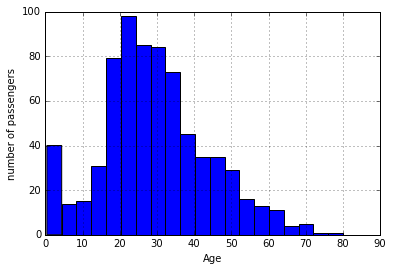

```python
age=titanic["Age"]
age.hist(bins=20)
plt.xlabel("Age")
plt.ylabel("number of passengers")
```

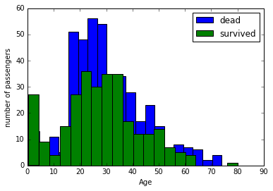

```python
ageby=titanic.groupby('Survived')["Age"]
ageby.plot.hist(stacked=True, bins=20)
plt.xlabel("Age")
plt.ylabel("number of passengers")
plt.legend(["dead","survived"])
```

## 2 passenger class and Fare

Most of 1st class passenger survived.

```
(-1.1086506003691148,
 1.0233212181911397,
 -1.0097985104171934,
 1.0240315425798225)
```

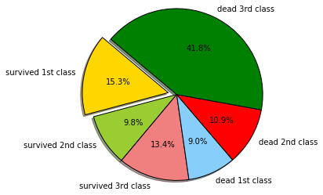

```python
s=titanic[titanic["Survived"]==1] #survived
d=titanic[titanic["Survived"]==0] #dead
s1=s[s["Pclass"]==1] # survived 1st class
s2=s[s["Pclass"]==2]# survived 2nd
s3=s[s["Pclass"]==3]
d1=d[d["Pclass"]==1] # dead 1st class
d2=d[d["Pclass"]==2]
d3=d[d["Pclass"]==3]

labels = 'survived 1st class', 'survived 2nd class', 'survived 3rd class', 'dead 1st class', 'dead 2nd class', 'dead 3rd class'
sizes = [s1.shape[0], s2.shape[0], s3.shape[0], d1.shape[0], d2.shape[0],d3.shape[0]]
colors = ['gold', 'yellowgreen', 'lightcoral', 'lightskyblue','red','green']
explode = (0.1, 0, 0, 0,0,0)  # explode 1st slice

# Plot
plt.pie(sizes, explode=explode, labels=labels, colors=colors,
        autopct='%1.1f%%', shadow=True, startangle=140)

plt.axis('equal')
```

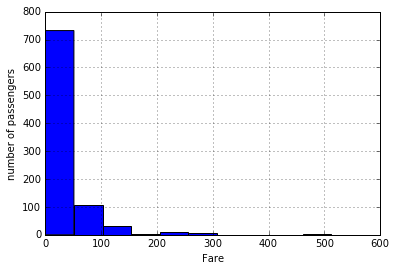

```python
fare=titanic["Fare"]
fare.hist()
plt.xlabel("Fare")
plt.ylabel("number of passengers")
```

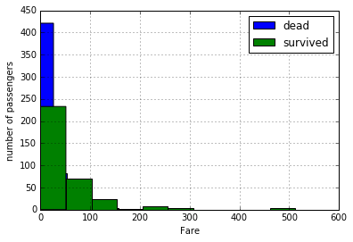

```python
fareby=titanic.groupby('Survived')["Fare"]
fareby.hist()
plt.xlabel("Fare")
plt.ylabel("number of passengers")
plt.legend(["dead","survived"])
```

## Gender

First, the string"male" is converted to 0 and "female" to 1.

```python
def convert_sex(sex):
    if sex=="male":
        return 0
    elif sex=="female":
        return 1

#titanic["Sex"]=titanic["Sex"].apply(convert_sex)
#titanic.corr()
```

```
(-1.1230770295538621,
 1.0080447044538756,
 -1.1650488632456442,
 1.0091337445244539)
```

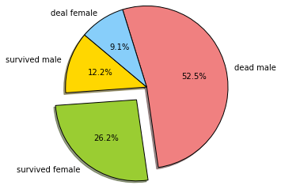

```python
s=titanic[titanic["Survived"]==1] #survived
d=titanic[titanic["Survived"]==0] #dead
sm=s[s["Sex"]=="male"] # survived male
sf=s[s["Sex"]=="female"]# survived female
dm=d[d["Sex"]=="male"]
df=d[d["Sex"]=="female"]

labels = 'survived male', 'survived female', 'dead male', 'deal female'
sizes = [sm.shape[0], sf.shape[0], dm.shape[0], df.shape[0]]
colors = ['gold', 'yellowgreen', 'lightcoral', 'lightskyblue']
explode = (0, 0.2, 0, 0)  # explode 2st slice

# Plot
plt.pie(sizes, explode=explode, labels=labels, colors=colors,
        autopct='%1.1f%%', shadow=True, startangle=140)

plt.axis('equal')
```

# Summary

## Conclusions

1. **Babies and women** have much higher survival rate than other group.
2. **Upper class** passengers have much higher survival rate than other group.

## Limitations

1. It seems groupby data doesn't have much plot methods. I still need to explore more to present better visualization.
2. The conclusions are not surprising, so it doesn't provide much insights. In contrary, insights can be gained by study the fatal rate. In hindsight, we know the **insufficient lifeboat** is a key factor that dominate the survival rate.